# Maumee

Jordyn Stoll

February 11, 2019 - April 3, 2019

MAUMEE ANALYSIS

Read in the data and look at some basic features (make sure it read in correctly)

```r
knitr::opts_chunk$set(echo = TRUE)
maumee1<- read.csv("~/Desktop/USGS/Maumee Species Counts.csv")
#remove initial sample

maumee<-maumee1[-c(1),]
names(maumee)
```

```
##  [1] "Lowest.taxonimic.Sample.ID" "Treatment"
##  [3] "Total.counted"              "Microcystis.spp."
##  [5] "Nitzschia.spp."             "Pseudoanabaena.spp."
##  [7] "Glaucocystis.spp..."        "morphospecies.10"
##  [9] "Aulacoseria.spp."           "Mougeotia.spp..."
## [11] "Diatoma.spp..."             "morphospecies.1"
## [13] "pollen."                    "Selenastraceae"
## [15] "morphospecies.2"            "morphospecies.3"
## [17] "Cyclotella.spp."            "morphospecies.4"
## [19] "Dolichospermum.spp."        "Aphanocapsa.spp.."
## [21] "morphospecies.5"            "Merismopedia.spp."
## [23] "Scenedesmus.spp."           "morphospecies.6"
## [25] "morphospecies.7"            "morphospecies.8"
## [27] "clamydomonadaceae.1"        "morphospecies.11"
## [29] "morphospecies.12"           "morphospecies.13"
```

[output cut: 20 more lines]

```r
dim(maumee)
```

```
## [1] 36 70
```

```r
head(maumee)
```

```
##   Lowest.taxonimic.Sample.ID Treatment Total.counted Microcystis.spp.
## 2                         37   Control           453              175
## 3                         38   Control           439              209
## 4                         39   Control           403              170
## 5                         40   Control           400              174
## 6                         41  Nitrogen           461              154
## 7                         42  Nitrogen           411              131
##   Nitzschia.spp. Pseudoanabaena.spp. Glaucocystis.spp... morphospecies.10
## 2             12                  29                   0                0
## 3             35                  17                   0                0
## 4             26                  10                   0                0
## 5             19                  11                   0                0
## 6             21                  16                   0                0
## 7             41                  28                   0                0
##   Aulacoseria.spp. Mougeotia.spp... Diatoma.spp... morphospecies.1 pollen.
```

[output cut: 111 more lines]

```r
str(maumee)
```

```
## 'data.frame':    36 obs. of  70 variables:
##  $ Lowest.taxonimic.Sample.ID: Factor w/ 37 levels "37","38","39",..: 1 2 3 4 5 6 7 8 9 10 ...
##  $ Treatment                 : Factor w/ 10 levels "Chelex","Control",..: 2 2 2 2 7 7 7 7 9 9 ...
##  $ Total.counted             : int  453 439 403 400 461 411 408 430 407 399 ...
##  $ Microcystis.spp.          : int  175 209 170 174 154 131 204 169 157 130 ...
##  $ Nitzschia.spp.            : int  12 35 26 19 21 41 31 19 17 29 ...
##  $ Pseudoanabaena.spp.       : int  29 17 10 11 16 28 27 34 30 6 ...
##  $ Glaucocystis.spp...       : int  0 0 0 0 0 0 0 0 0 0 ...
##  $ morphospecies.10          : int  0 0 0 0 0 0 0 0 0 0 ...
##  $ Aulacoseria.spp.          : int  15 0 0 0 0 16 0 2 0 10 ...
##  $ Mougeotia.spp...          : int  98 63 67 83 102 75 48 49 51 70 ...
##  $ Diatoma.spp...            : int  1 0 0 0 6 0 2 0 0 0 ...
##  $ morphospecies.1           : int  0 0 1 0 0 0 0 0 0 0 ...
##  $ pollen.                   : int  0 0 0 0 4 2 1 3 0 2 ...
##  $ Selenastraceae            : int  9 1 3 1 4 2 2 1 8 2 ...
```

[output cut: 56 more lines]

Calculate species richness

```r
# Total caught per species
maum.colsums=apply(maumee[,4:70],2,sum)
# Total number of fish per sampe
maum.rowsums=apply(maumee[,4:70],1,sum)
#check out what we did
maum.colsums
```

```
##    Microcystis.spp.      Nitzschia.spp. Pseudoanabaena.spp.
##                5475                 940                 596
## Glaucocystis.spp...    morphospecies.10    Aulacoseria.spp.
##                   3                   9                 397
##    Mougeotia.spp...      Diatoma.spp...     morphospecies.1
##                2900                  64                   6
##             pollen.      Selenastraceae     morphospecies.2
##                  14                 153                   6
##     morphospecies.3     Cyclotella.spp.     morphospecies.4
##                  18                 727                  42
## Dolichospermum.spp.   Aphanocapsa.spp..     morphospecies.5
##                   4                  44                  44
##   Merismopedia.spp.    Scenedesmus.spp.     morphospecies.6
##                 197                 108                  63
##     morphospecies.7     morphospecies.8 clamydomonadaceae.1
##                   7                  63                  46
##    morphospecies.11    morphospecies.12    morphospecies.13
##                 508                   0                  12
##      Westella.spp..     Melosira.spp...    morphospecies.14
##                   5                1654                  91
##    morphospecies.15    morphospecies.16     Unidentified.13
##                  69                  11                  28
##    Spirulina.spp...     Tetraedron.spp. Cycyotella.spp..2..
##                  92                   3                 809
##  Thalassiosira.spp. Micractinium.spp...    morphospecies.17
##                 110                  31                   1
##    morphospecies.18    morphospecies.19    morphospecies.20
##                  29                  15                  54
## clamydomonadaceae.2    morphospecies.21      Dinobryon.spp.
##                  21                  66                   9
##    morphospecies.22    morphospecies.23    morphospecies.24
##                  16                  17                   1
##    morphospecies.25    morphospecies.26    morphospecies.27
##                  25                   5                   7
##    morphospecies.28    morphospecies.29  Tetraselmis.spp...
##                   2                  23                  23
##    morphospecies.30    morphospecies.31  Kirchneriella.spp.
##                   1                  36                   3
##    morphospecies.32   Tetraedron.spp..2    Dinobryon.spp..1
##                   3                   1                   5
##  Desmodesmus.spp...    Selenastrum.spp.     Unidentified.33
##                   4                   7                   4
##        Euglena.spp.         Phacus.spp.     Unidentified.34
##                   5                   1                   7
##      Treubaria.spp.
##                   1
```

```r
maum.rowsums
```

```
##   2   3   4   5   6   7   8   9  10  11  12  13  14  15  16  17  18  19
## 453 439 403 400 461 411 408 430 407 399 411 447 408 427 455 442 442 470
##  20  21  22  23  24  25  26  27  28  29  30  31  32  33  34  35  36  37
## 421 439 498 451 426 436 472 453 482 465 472 446 420 416 447 441 428 415
```

```r
# Its so easy to calculate richness, right?  Well, maybe...
maum.rich=apply(maumee[,4:70]>0,1,sum)
maum.rich
```

```
##  2  3  4  5  6  7  8  9 10 11 12 13 14 15 16 17 18 19 20 21 22 23 24 25 26
## 22 15 22 24 30 24 21 23 24 24 28 32 20 17 23 20 25 32 25 31 23 29 24 19 37
## 27 28 29 30 31 32 33 34 35 36 37
## 22 28 42 29 22 25 27 25 26 27 18
```

```r
# add total catch and raw richness to the dataset for future use, and look at the lowest number of fish caught in a sample
#cbind stands for column bind, so we are combining the dataset info, richness and rowsums
cbind(maumee[,1:2],maum.rich,maum.rowsums)
```

```
##    Lowest.taxonimic.Sample.ID  Treatment maum.rich maum.rowsums
## 2                          37    Control        22          453
## 3                          38    Control        15          439
## 4                          39    Control        22          403
## 5                          40    Control        24          400
## 6                          41   Nitrogen        30          461
## 7                          42   Nitrogen        24          411
## 8                          43   Nitrogen        21          408
## 9                          44   Nitrogen        23          430
## 10                         45 Phosphorus        24          407
## 11                         46 Phosphorus        24          399
## 12                         47 Phosphorus        28          411
## 13                         48 Phosphorus        32          447
## 14                         49      Trace        20          408
## 15                         50      Trace        17          427
```

[output cut: 22 more lines]

```r
min(maum.rowsums)
```

```
## [1] 399
```

```r
#helps to determine how many sites you would exclude during rarefaction
as.data.frame(table(maum.rowsums))
```

```
##    maum.rowsums Freq
## 1           399    1
## 2           400    1
## 3           403    1
## 4           407    1
## 5           408    2
## 6           411    2
## 7           415    1
## 8           416    1
## 9           420    1
## 10          421    1
## 11          426    1
## 12          427    1
## 13          428    1
## 14          430    1
## 15          436    1
## 16          439    2
## 17          441    1
## 18          442    2
## 19          446    1
## 20          447    2
## 21          451    1
## 22          453    2
## 23          455    1
## 24          461    1
## 25          465    1
## 26          470    1
## 27          472    2
## 28          482    1
## 29          498    1
```

Individual based rarefaction

```r
library(vegan)
```

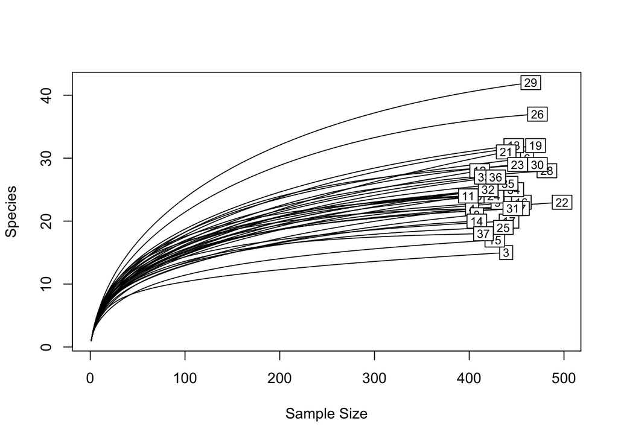

```r
# Using the rarefaction formula to find expected species richness
rarecurve(maumee[,4:70])
```

```r
# You can choose a minimum sample size to rarefy all samples to using the command below
#uses formulas from Gotelli et al
rarefy(maumee[,4:70],sample=399)
```

```
##        2        3        4        5        6        7        8        9
## 21.58465 14.62666 21.93030 23.97750 28.86636 23.90767 20.86591 22.69575
##       10       11       12       13       14       15       16       17
## 23.94000 24.00000 27.70564 31.04887 19.93079 16.72912 22.43108 19.67108
##       18       19       20       21       22       23       24       25
## 24.55425 30.58087 24.57112 29.76604 21.92225 28.20024 23.72249 18.80096
##       26       27       28       29       30       31       32       33
## 35.90784 21.58465 26.97073 40.49168 28.28675 21.93342 24.68773 26.70589
##       34       35       36       37
## 24.47852 25.39050 26.43536 17.95725
## attr(,"Subsample")
## [1] 399
```

```r
#could store to analyze later
```

Shannon Diversity Hill Numbers

```r
diversity(maumee[,4:70],index="shannon")
```

```
##        2        3        4        5        6        7        8        9
## 2.034390 1.739454 1.969522 1.936441 2.278541 2.256906 1.814903 2.150873
##       10       11       12       13       14       15       16       17
## 2.279787 2.194568 2.271968 2.388018 1.786471 1.657891 2.015676 2.151910
##       18       19       20       21       22       23       24       25
## 2.076632 2.238071 1.973475 2.150752 2.254356 2.227794 1.952152 1.937024
##       26       27       28       29       30       31       32       33
## 2.475325 2.034390 2.330242 2.602905 2.332774 2.395928 2.175281 2.093190
##       34       35       36       37
## 2.178076 2.081399 2.129789 2.100211
```

```r
# Hill and Renyi numbers are calculated by this command- exponentiates the shannon values
renyi(maumee[,4:70], hill=TRUE)
```

```
##     0     0.25       0.5         1        2        4        8       16
## 2  22 16.49085 12.388898  7.647584 4.626305 3.437971 2.961212 2.758003
## 3  15 11.02170  8.449781  5.694235 3.662714 2.679458 2.335388 2.207019
## 4  22 15.75175 11.535878  7.167246 4.378427 3.132095 2.681455 2.510999
## 5  24 16.92297 12.015395  6.934029 4.051043 2.982248 2.588147 2.430028
## 6  30 22.23099 16.430361  9.762427 5.602241 4.062214 3.482962 3.220222
## 7  24 18.41341 14.314265  9.553481 6.132547 4.417500 3.687996 3.385879
## 8  21 14.80573 10.559722  6.140480 3.499643 2.515522 2.208175 2.094588
## 9  23 17.47588 13.407870  8.592355 5.062425 3.454731 2.907478 2.707825
## 10 24 19.03580 15.082870  9.774595 5.390641 3.544337 2.970203 2.762323
## 11 24 18.21985 13.907413  8.976125 5.762515 4.280056 3.597963 3.307476
## 12 28 20.61930 15.392977  9.698470 6.049529 4.364235 3.628509 3.331623
## 13 32 23.77310 17.713861 10.891882 6.556489 4.724789 3.975743 3.643459
## 14 20 14.27554 10.225743  5.968355 3.603273 2.764152 2.437232 2.298294
## 15 17 12.01309  8.643747  5.248229 3.409102 2.751617 2.470400 2.332639
```

[output cut: 59 more lines]

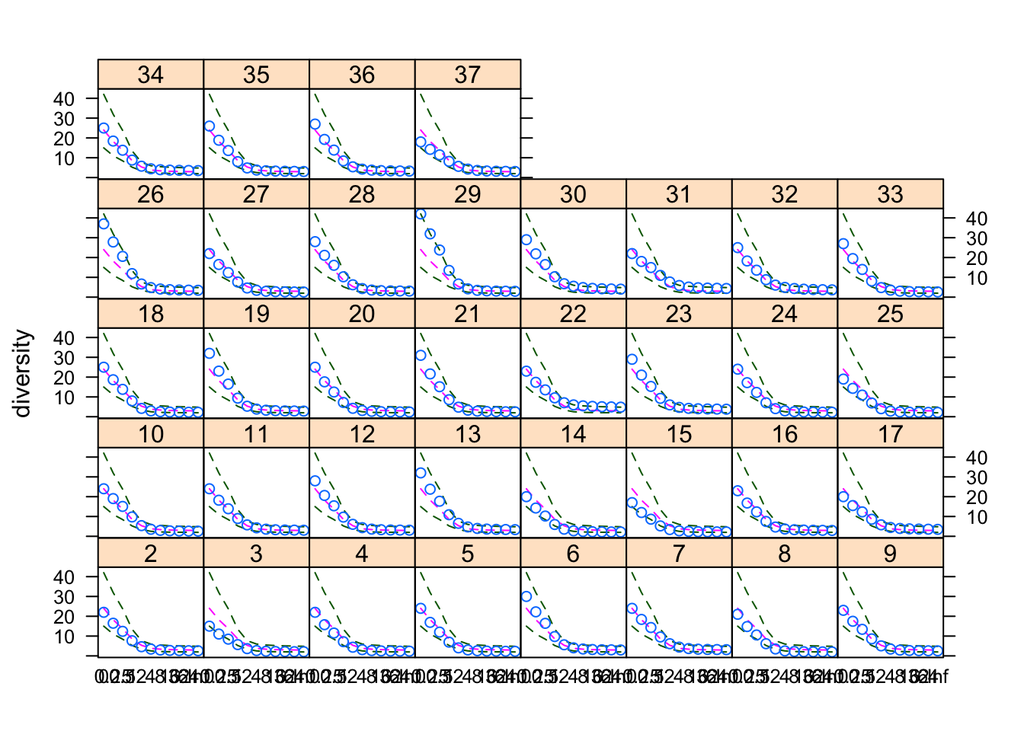

```r
plot(renyi(maumee[,4:70], hill=TRUE))
```

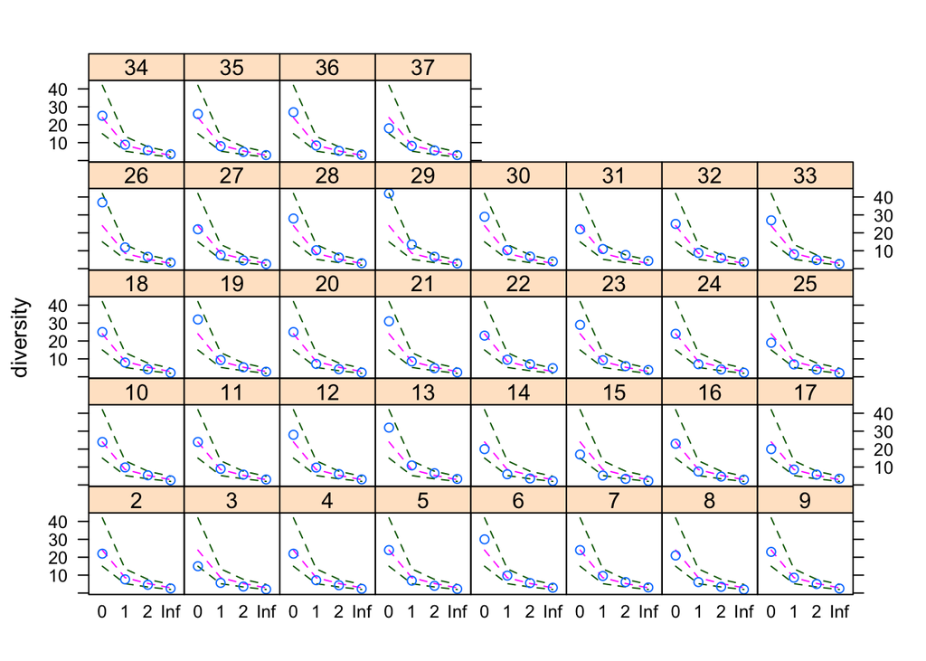

```r
plot(renyi(maumee[,4:70], scales=c(0,1,2,Inf), hill=TRUE))
```

Rarefaction

```r
#rarefy to 399
maum.rare<-rrarefy(maumee[,4:70], sample=399)
head(rrarefy(maumee[,4:70],sample=399))
```

```
##   Microcystis.spp. Nitzschia.spp. Pseudoanabaena.spp. Glaucocystis.spp...
## 2              156             12                  23                   0
## 3              190             31                  14                   0
## 4              170             25                   9                   0
## 5              173             19                  11                   0
## 6              137             14                  14                   0
## 7              128             40                  28                   0
##   morphospecies.10 Aulacoseria.spp. Mougeotia.spp... Diatoma.spp...
## 2                0               14               82              1
## 3                0                0               60              0
## 4                0                0               67              0
## 5                0                0               83              0
## 6                0                0               87              4
## 7                0               16               71              0
##   morphospecies.1 pollen. Selenastraceae morphospecies.2 morphospecies.3
```

[output cut: 104 more lines]

Run simulations (each is slightly different, so run a lot, then average)

```r
nperm=100
n=nrow(maumee[maum.rowsums>0,])
p=ncol(maumee[,4:70])
#matrix to store the results
renyi.indperms=matrix(nrow=n,ncol=4*nperm)

for(i in 1:nperm){
    maum.rare=rrarefy(maumee[maum.rowsums>0,4:70],sample=399)
    cols=(1+(i-1)*4):(i*4)
    renyi.rare=renyi(maum.rare, scales=c(0,1,2,Inf), hill=TRUE)
    renyi.indperms[,cols]=as.matrix(renyi.rare)
}
maxperm=nperm*4
head(renyi.indperms)
```

```
##      [,1]     [,2]     [,3]     [,4] [,5]     [,6]     [,7]     [,8] [,9]
## [1,]   22 7.628747 4.561764 2.574194   20 7.182816 4.467546 2.557692   21
## [2,]   15 5.834120 3.814020 2.168478   15 5.798962 3.722346 2.122340   14
## [3,]   22 7.159784 4.358686 2.360947   22 7.120345 4.353918 2.360947   22
## [4,]   24 6.953214 4.066541 2.306358   24 6.940271 4.047723 2.293103   24
## [5,]   28 9.640421 5.536848 3.000000   27 9.424324 5.502782 2.977612   30
## [6,]   24 9.536895 6.166996 3.166667   24 9.489685 6.134677 3.141732   24
##         [,10]    [,11]    [,12] [,13]    [,14]    [,15]    [,16] [,17]
## [1,] 7.271195 4.377623 2.478261    22 7.833870 4.807519 2.751724    21
## [2,] 5.606644 3.624878 2.089005    15 5.627620 3.624217 2.089005    15
## [3,] 7.101031 4.343464 2.360947    22 7.129232 4.326232 2.347059    22
## [4,] 6.953214 4.066541 2.306358    24 6.953214 4.066541 2.306358    24
## [5,] 9.647289 5.485717 2.933824    29 9.630516 5.545334 2.955556    28
## [6,] 9.471723 6.095218 3.117188    24 9.502930 6.227790 3.217742    24
##         [,18]    [,19]    [,20] [,21]    [,22]    [,23]    [,24] [,25]
```

[output cut: 335 more lines]

Average permuations to yield rarefied, average hill numbers

```r
maum.hills=cbind(maumee[,c(2,3)],
    apply(renyi.indperms[,seq(from=1,to=(maxperm-3),by=4)],1,mean),
    apply(renyi.indperms[,seq(from=2,to=(maxperm-2),by=4)],1,mean),
    apply(renyi.indperms[,seq(from=3,to=(maxperm-1),by=4)],1,mean),
    apply(renyi.indperms[,seq(from=4,to=maxperm,by=4)],1,mean))
colnames(maum.hills)=c("TREATMENT","# COUNTED","H0","H1","H2","HInf")
maum.hills
```

```
##     TREATMENT # COUNTED    H0        H1       H2     HInf
## 2     Control       453 21.61  7.627029 4.627580 2.591309
## 3     Control       439 14.63  5.689963 3.671652 2.104987
## 4     Control       403 21.91  7.157942 4.374581 2.369156
## 5     Control       400 23.99  6.931097 4.048394 2.297610
## 6    Nitrogen       461 29.03  9.723826 5.604757 2.993950
## 7    Nitrogen       411 23.95  9.548616 6.131513 3.137046
## 8    Nitrogen       408 20.89  6.133206 3.498235 1.999503
## 9    Nitrogen       430 22.67  8.553867 5.056040 2.544608
## 10 Phosphorus       407 23.91  9.752275 5.383594 2.591266
## 11 Phosphorus       399 24.00  8.976125 5.762515 3.069231
## 12 Phosphorus       411 27.70  9.666424 6.031925 3.082975
## 13 Phosphorus       447 31.21 10.868541 6.565504 3.372120
## 14      Trace       408 19.90  5.964303 3.599860 2.179209
## 15      Trace       427 16.78  5.244092 3.410733 2.212287
```

[output cut: 22 more lines]

```r
# Why are richness Hill nubers not whole numbers??
#add columns for treatments n,p,trace as y/n for analysis of interactive effects
maum.hills$trace<-grepl("Trace", maum.hills$TREATMENT)
maum.hills$nitrogen<-grepl("N", maum.hills$TREATMENT)
maum.hills$phosphorus<-grepl("P", maum.hills$TREATMENT)
```

ANOVA on Hill numbers

```r
#not considering significance from the intitial sample. Counts for the initial are biased (long story) so I'm not considering them in my statistical analysis currently.

#Richness
maumeeRICHNESSaov<-aov(H0~nitrogen*phosphorus*trace, data=maum.hills)
shapiro.test(resid(maumeeRICHNESSaov))
```

```
##
##  Shapiro-Wilk normality test
##
## data:  resid(maumeeRICHNESSaov)
## W = 0.98091, p-value = 0.7755
```

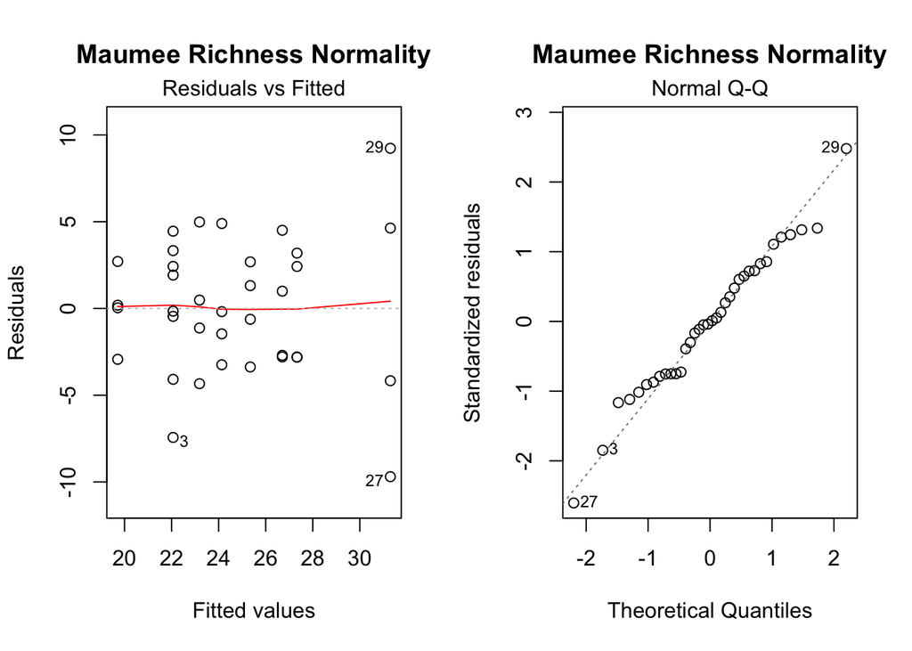

```r
par(mfrow=c(1,2))
plot(maumeeRICHNESSaov,which=c(1,2), main="Maumee Richness Normality")
```

```r
summary(maumeeRICHNESSaov)
```

```
##                           Df Sum Sq Mean Sq F value  Pr(>F)
## nitrogen                   1  162.8  162.78   8.807 0.00608 **
## phosphorus                 1   88.7   88.74   4.801 0.03693 *
## trace                      1   38.9   38.94   2.107 0.15775
## nitrogen:phosphorus        1    4.5    4.48   0.242 0.62635
## nitrogen:trace             1    4.7    4.68   0.253 0.61884
## phosphorus:trace           1   51.2   51.23   2.772 0.10710
## nitrogen:phosphorus:trace  1   34.0   33.99   1.839 0.18588
## Residuals                 28  517.5   18.48
## ---
## Signif. codes:  0 '***' 0.001 '**' 0.01 '*' 0.05 '.' 0.1 ' ' 1
```

```r
#nitrogen, phosphorus significant
maumeeRICHNESSaov2<-aov(H0~TREATMENT, data=maum.hills)
summary(maumeeRICHNESSaov2)
```

```
##             Df Sum Sq Mean Sq F value Pr(>F)
## TREATMENT    8  403.6   50.45   2.731  0.024 *
## Residuals   27  498.8   18.47
## ---
## Signif. codes:  0 '***' 0.001 '**' 0.01 '*' 0.05 '.' 0.1 ' ' 1
```

```r
TukeyHSD(maumeeRICHNESSaov2)
```

```
##   Tukey multiple comparisons of means
##     95% family-wise confidence level
##
## Fit: aov(formula = H0 ~ TREATMENT, data = maum.hills)
##
## $TREATMENT
##                          diff         lwr       upr     p adj
## Control-Chelex        -3.0625 -13.2885278  7.163528 0.9818124
## N+P-Chelex             7.7000  -2.5260278 17.926028 0.2605572
## N+P+Trace-Chelex       1.7475  -8.4785278 11.973528 0.9996056
## N+Trace-Chelex         3.7325  -6.4935278 13.958528 0.9428085
## Nitrogen-Chelex        0.5375  -9.6885278 10.763528 1.0000000
## P+Trace-Chelex        -0.4100 -10.6360278  9.816028 1.0000000
## Phosphorus-Chelex      3.1075  -7.1185278 13.333528 0.9801150
## Trace-Chelex          -3.8850 -14.1110278  6.341028 0.9292195
## N+P-Control           10.7625   0.5364722 20.988528 0.0334848
## N+P+Trace-Control      4.8100  -5.4160278 15.036028 0.8056173
## N+Trace-Control        6.7950  -3.4310278 17.021028 0.4125207
## Nitrogen-Control       3.6000  -6.6260278 13.826028 0.9530909
## P+Trace-Control        2.6525  -7.5735278 12.878528 0.9927050
## Phosphorus-Control     6.1700  -4.0560278 16.396028 0.5372074
## Trace-Control         -0.8225 -11.0485278  9.403528 0.9999988
## N+P+Trace-N+P         -5.9525 -16.1785278  4.273528 0.5823985
## N+Trace-N+P           -3.9675 -14.1935278  6.258528 0.9210631
## Nitrogen-N+P          -7.1625 -17.3885278  3.063528 0.3458748
## P+Trace-N+P           -8.1100 -18.3360278  2.116028 0.2060412
## Phosphorus-N+P        -4.5925 -14.8185278  5.633528 0.8407709
## Trace-N+P            -11.5850 -21.8110278 -1.358972 0.0176893
## N+Trace-N+P+Trace      1.9850  -8.2410278 12.211028 0.9990068
## Nitrogen-N+P+Trace    -1.2100 -11.4360278  9.016028 0.9999752
## P+Trace-N+P+Trace     -2.1575 -12.3835278  8.068528 0.9982079
## Phosphorus-N+P+Trace   1.3600  -8.8660278 11.586028 0.9999394
## Trace-N+P+Trace       -5.6325 -15.8585278  4.593528 0.6487754
## Nitrogen-N+Trace      -3.1950 -13.4210278  7.031028 0.9764795
## P+Trace-N+Trace       -4.1425 -14.3685278  6.083528 0.9018600
## Phosphorus-N+Trace    -0.6250 -10.8510278  9.601028 0.9999999
## Trace-N+Trace         -7.6175 -17.8435278  2.608528 0.2726438
## P+Trace-Nitrogen      -0.9475 -11.1735278  9.278528 0.9999963
## Phosphorus-Nitrogen    2.5700  -7.6560278 12.796028 0.9940775
## Trace-Nitrogen        -4.4225 -14.6485278  5.803528 0.8657799
## Phosphorus-P+Trace     3.5175  -6.7085278 13.743528 0.9588051
## Trace-P+Trace         -3.4750 -13.7010278  6.751028 0.9615498
## Trace-Phosphorus      -6.9925 -17.2185278  3.233528 0.3759400
```

```r
#N+P-control
#N+P-trace

#Exponential Shannon Entropy (Shannon Hill)
maumeeSHANNONaov<-aov(H1~nitrogen*phosphorus*trace, data=maum.hills)
shapiro.test(resid(maumeeSHANNONaov))
```

```
##
##  Shapiro-Wilk normality test
##
## data:  resid(maumeeSHANNONaov)
## W = 0.97886, p-value = 0.7068
```

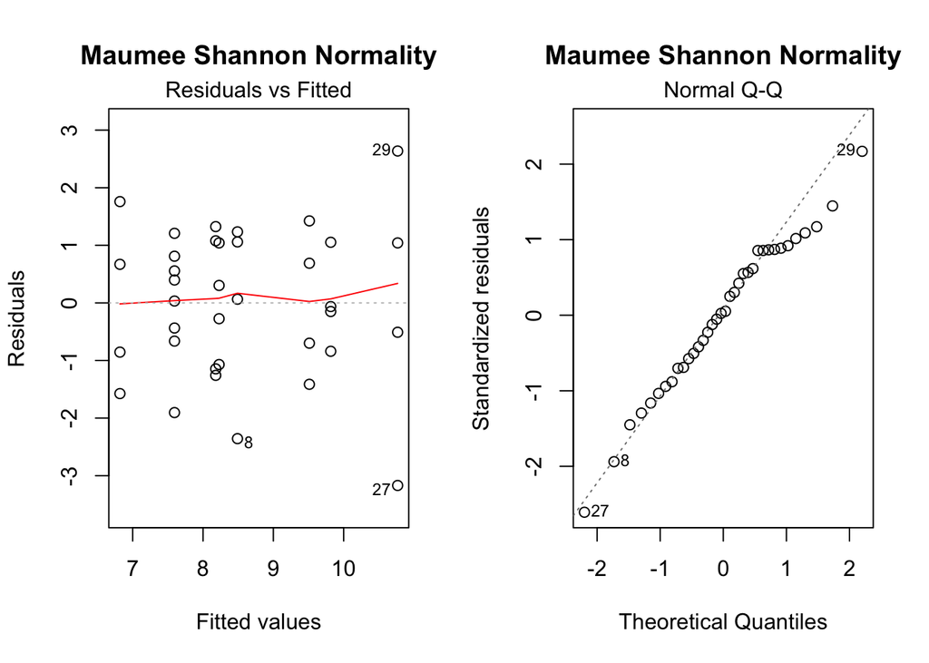

```r
par(mfrow=c(1,2))
plot(maumeeSHANNONaov,which=c(1,2), main="Maumee Shannon Normality")
```

```r
summary(maumeeSHANNONaov)
```

```
##                           Df Sum Sq Mean Sq F value  Pr(>F)
## nitrogen                   1  13.86  13.859   7.033 0.01303 *
## phosphorus                 1  25.92  25.918  13.152 0.00113 **
## trace                      1   8.11   8.114   4.117 0.05205 .
## nitrogen:phosphorus        1   0.00   0.004   0.002 0.96438
## nitrogen:trace             1   0.32   0.320   0.163 0.68983
## phosphorus:trace           1   1.82   1.822   0.925 0.34451
## nitrogen:phosphorus:trace  1   0.01   0.010   0.005 0.94482
## Residuals                 28  55.18   1.971
## ---
## Signif. codes:  0 '***' 0.001 '**' 0.01 '*' 0.05 '.' 0.1 ' ' 1
```

```r
#N, P significant
maumeeSHANNONaov2<-aov(H1~TREATMENT, data=maum.hills)
summary(maumeeSHANNONaov2)
```

```
##             Df Sum Sq Mean Sq F value  Pr(>F)
## TREATMENT    8  54.46   6.808   3.621 0.00556 **
## Residuals   27  50.76   1.880
## ---
## Signif. codes:  0 '***' 0.001 '**' 0.01 '*' 0.05 '.' 0.1 ' ' 1
```

```r
TukeyHSD(maumeeSHANNONaov2)
```

```
##   Tukey multiple comparisons of means
##     95% family-wise confidence level
##
## Fit: aov(formula = H1 ~ TREATMENT, data = maum.hills)
##
## $TREATMENT
##                             diff        lwr        upr     p adj
## Control-Chelex       -1.48561265 -4.7479003  1.7766750 0.8307289
## N+P-Chelex            2.43014572 -0.8321419  5.6924334 0.2726319
## N+P+Trace-Chelex      1.17501007 -2.0872776  4.4372977 0.9467960
## N+Trace-Chelex       -0.10869992 -3.3709876  3.1535877 1.0000000
## Nitrogen-Chelex       0.15275828 -3.1095294  3.4150460 1.0000000
## P+Trace-Chelex       -0.15639988 -3.4186876  3.1058878 1.0000000
## Phosphorus-Chelex     1.47872090 -1.7835668  4.7410086 0.8341355
## Trace-Chelex         -1.51848102 -4.7807687  1.7438067 0.8140181
## N+P-Control           3.91575837  0.6534707  7.1780460 0.0101806
## N+P+Trace-Control     2.66062272 -0.6016649  5.9229104 0.1794446
## N+Trace-Control       1.37691273 -1.8853749  4.6392004 0.8802572
## Nitrogen-Control      1.63837093 -1.6239167  4.9006586 0.7472410
## P+Trace-Control       1.32921277 -1.9330749  4.5915004 0.8990154
## Phosphorus-Control    2.96433354 -0.2979541  6.2266212 0.0969264
## Trace-Control        -0.03286837 -3.2951560  3.2294193 1.0000000
## N+P+Trace-N+P        -1.25513565 -4.5174233  2.0071520 0.9244070
## N+Trace-N+P          -2.53884565 -5.8011333  0.7234420 0.2251360
## Nitrogen-N+P         -2.27738744 -5.5396751  0.9849002 0.3499928
## P+Trace-N+P          -2.58654561 -5.8488333  0.6757421 0.2063051
## Phosphorus-N+P       -0.95142483 -4.2137125  2.3108628 0.9845627
## Trace-N+P            -3.94862674 -7.2109144 -0.6863391 0.0093631
## N+Trace-N+P+Trace    -1.28371000 -4.5459977  1.9785777 0.9151529
## Nitrogen-N+P+Trace   -1.02225179 -4.2845395  2.2400359 0.9760630
## P+Trace-N+P+Trace    -1.33140996 -4.5936976  1.9308777 0.8981926
## Phosphorus-N+P+Trace  0.30371082 -2.9585768  3.5659985 0.9999961
## Trace-N+P+Trace      -2.69349109 -5.9557788  0.5687966 0.1684322
## Nitrogen-N+Trace      0.26145821 -3.0008295  3.5237459 0.9999988
## P+Trace-N+Trace      -0.04769996 -3.3099876  3.2145877 1.0000000
## Phosphorus-N+Trace    1.58742082 -1.6748669  4.8497085 0.7766463
## Trace-N+Trace        -1.40978109 -4.6720688  1.8525066 0.8662531
## P+Trace-Nitrogen     -0.30915817 -3.5714458  2.9531295 0.9999955
## Phosphorus-Nitrogen   1.32596261 -1.9363251  4.5882503 0.9002251
## Trace-Nitrogen       -1.67123930 -4.9335270  1.5910484 0.7275841
## Phosphorus-P+Trace    1.63512078 -1.6271669  4.8974084 0.7491571
## Trace-P+Trace        -1.36208113 -4.6243688  1.9002065 0.8862901
## Trace-Phosphorus     -2.99720191 -6.2594896  0.2650858 0.0903309
```

```r
#N+P-control
#Trace-N+P

#Exponential Inverse Simpson Entropy (Simpson Hill)
#this indice and the ones below are more concerned with species evenness, whereas the above are more richness based
maumeeSIMPSONaov<-aov(H2~nitrogen*phosphorus*trace, data=maum.hills)
shapiro.test(resid(maumeeSIMPSONaov))
```

```
##
##  Shapiro-Wilk normality test
##
## data:  resid(maumeeSIMPSONaov)
## W = 0.97475, p-value = 0.5685
```

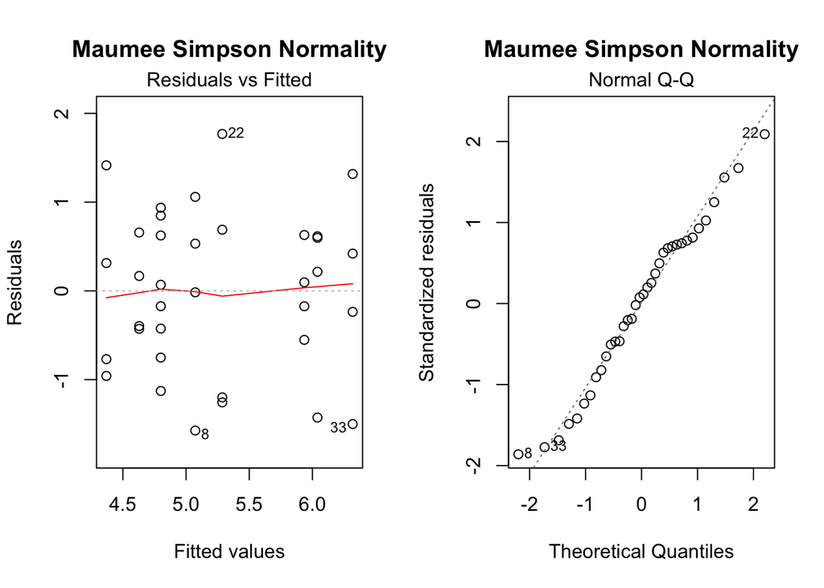

```r
par(mfrow=c(1,2))
plot(maumeeSIMPSONaov,which=c(1,2), main="Maumee Simpson Normality")
```

```r
summary(maumeeSIMPSONaov)
```

```
##                           Df Sum Sq Mean Sq F value  Pr(>F)
## nitrogen                   1  2.019   2.019   2.114 0.15707
## phosphorus                 1 11.127  11.127  11.650 0.00197 **
## trace                      1  0.972   0.972   1.017 0.32182
## nitrogen:phosphorus        1  0.222   0.222   0.233 0.63325
## nitrogen:trace             1  0.421   0.421   0.441 0.51217
## phosphorus:trace           1  0.104   0.104   0.109 0.74366
## nitrogen:phosphorus:trace  1  0.472   0.472   0.495 0.48767
## Residuals                 28 26.743   0.955
## ---
## Signif. codes:  0 '***' 0.001 '**' 0.01 '*' 0.05 '.' 0.1 ' ' 1
```

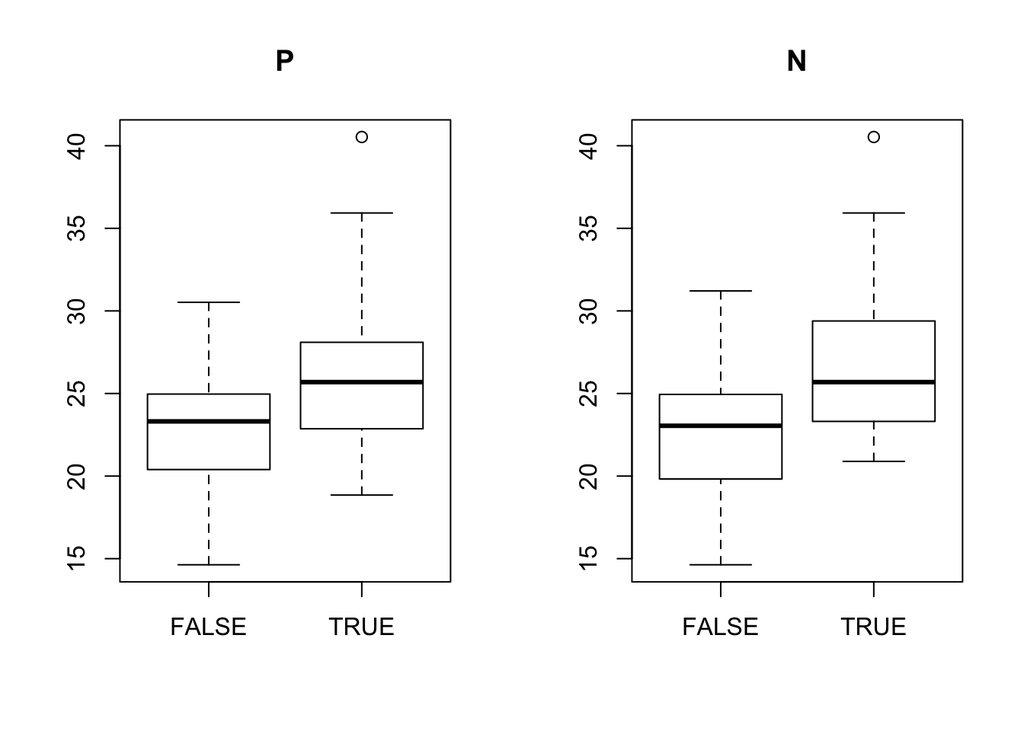

```r
boxplot(H0~phosphorus, data=maum.hills, main="P")
boxplot(H0~nitrogen, data=maum.hills, main="N")
```

```r
#P significant

maumeeSIMPSONaov2<-aov(H2~TREATMENT, data=maum.hills)
summary(maumeeSIMPSONaov2)
```

```
##             Df Sum Sq Mean Sq F value Pr(>F)
## TREATMENT    8  18.41  2.3011   2.625 0.0288 *
## Residuals   27  23.67  0.8767
## ---
## Signif. codes:  0 '***' 0.001 '**' 0.01 '*' 0.05 '.' 0.1 ' ' 1
```

```r
TukeyHSD(maumeeSIMPSONaov2)
```

```
##   Tukey multiple comparisons of means
##     95% family-wise confidence level
##
## Fit: aov(formula = H2 ~ TREATMENT, data = maum.hills)
##
## $TREATMENT
##                            diff         lwr       upr     p adj
## Control-Chelex       -1.2391732 -3.46690761 0.9885613 0.6373010
## N+P-Chelex            0.6199792 -1.60775523 2.8477137 0.9885041
## N+P+Trace-Chelex      0.8989673 -1.32876718 3.1267017 0.9037173
## N+Trace-Chelex       -0.7905557 -3.01829011 1.4371788 0.9509654
## Nitrogen-Chelex      -0.3470890 -2.57482346 1.8806454 0.9998008
## P+Trace-Chelex       -0.1331833 -2.36091771 2.0945512 0.9999999
## Phosphorus-Chelex     0.5161594 -1.71157502 2.7438939 0.9965737
## Trace-Chelex         -1.0501991 -3.27793357 1.1775353 0.8037930
## N+P-Control           1.8591524 -0.36858207 4.0868868 0.1591508
## N+P+Trace-Control     2.1381404 -0.08959402 4.3658749 0.0673333
## N+Trace-Control       0.4486175 -1.77911695 2.6763520 0.9987097
## Nitrogen-Control      0.8920842 -1.33565029 3.1198186 0.9073335
## P+Trace-Control       1.1059899 -1.12174455 3.3337244 0.7582294
## Phosphorus-Control    1.7553326 -0.47240186 3.9830670 0.2125023
## Trace-Control         0.1889740 -2.03876041 2.4167085 0.9999981
## N+P+Trace-N+P         0.2789880 -1.94874640 2.5067225 0.9999617
## N+Trace-N+P          -1.4105349 -3.63826933 0.8171996 0.4750309
## Nitrogen-N+P         -0.9670682 -3.19480268 1.2606662 0.8634301
## P+Trace-N+P          -0.7531625 -2.98089693 1.4745720 0.9626562
## Phosphorus-N+P       -0.1038198 -2.33155424 2.1239147 1.0000000
## Trace-N+P            -1.6701783 -3.89791279 0.5575561 0.2653962
## N+Trace-N+P+Trace    -1.6895229 -3.91725738 0.5382115 0.2526423
## Nitrogen-N+P+Trace   -1.2460563 -3.47379072 0.9816782 0.6307713
## P+Trace-N+P+Trace    -1.0321505 -3.25988498 1.1955839 0.8176415
## Phosphorus-N+P+Trace -0.3828078 -2.61054229 1.8449266 0.9995892
## Trace-N+P+Trace      -1.9491664 -4.17690084 0.2785681 0.1220725
## Nitrogen-N+Trace      0.4434667 -1.78426780 2.6712011 0.9988113
## P+Trace-N+Trace       0.6573724 -1.57036206 2.8851068 0.9833967
## Phosphorus-N+Trace    1.3067151 -0.92101937 3.5344495 0.5728698
## Trace-N+Trace        -0.2596435 -2.48737791 1.9680910 0.9999779
## P+Trace-Nitrogen      0.2139057 -2.01382871 2.4416402 0.9999951
## Phosphorus-Nitrogen   0.8632484 -1.36448602 3.0909829 0.9215644
## Trace-Nitrogen       -0.7031101 -2.93084456 1.5246243 0.9750112
## Phosphorus-P+Trace    0.6493427 -1.57839176 2.8770771 0.9846161
## Trace-P+Trace        -0.9170159 -3.14475031 1.3107186 0.8938342
## Trace-Phosphorus     -1.5663585 -3.79409300 0.6613759 0.3411268
```

```r
#NPtrace- control nearly significant

#Exponential Berger Parker (BP Hill)
maumeeBPaov<-aov(HInf~nitrogen*phosphorus*trace, data=maum.hills)
shapiro.test(resid(maumeeBPaov))
```

```
##
##  Shapiro-Wilk normality test
##
## data:  resid(maumeeBPaov)
## W = 0.97611, p-value = 0.6135
```

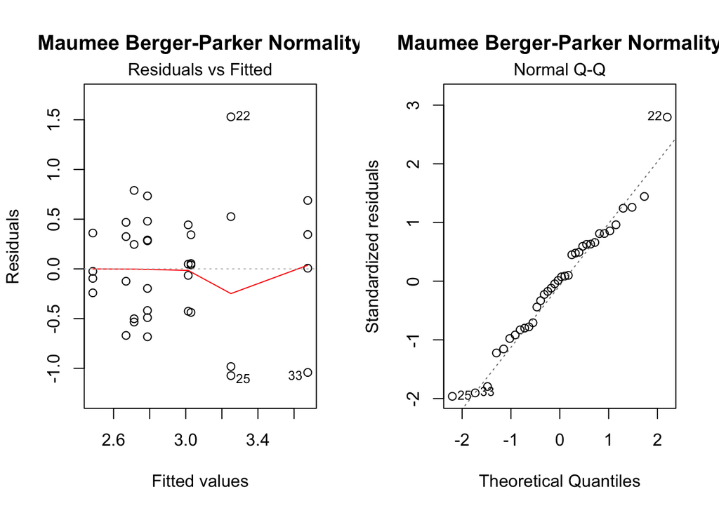

```r
par(mfrow=c(1,2))
plot(maumeeBPaov,which=c(1,2), main="Maumee Berger-Parker Normality")
```

```r
summary(maumeeBPaov)
```

```
##                           Df Sum Sq Mean Sq F value Pr(>F)
## nitrogen                   1  0.020  0.0198   0.050 0.8254
## phosphorus                 1  2.705  2.7054   6.781 0.0146 *
## trace                      1  0.129  0.1288   0.323 0.5744
## nitrogen:phosphorus        1  0.372  0.3722   0.933 0.3424
## nitrogen:trace             1  0.075  0.0751   0.188 0.6677
## phosphorus:trace           1  0.654  0.6542   1.640 0.2109
## nitrogen:phosphorus:trace  1  0.162  0.1619   0.406 0.5292
## Residuals                 28 11.171  0.3990
## ---
## Signif. codes:  0 '***' 0.001 '**' 0.01 '*' 0.05 '.' 0.1 ' ' 1
```

```r
#P significant

maumeeBPaov2<-aov(HInf~TREATMENT, data=maum.hills)
summary(maumeeBPaov2)
```

```
##             Df Sum Sq Mean Sq F value Pr(>F)
## TREATMENT    8  5.715  0.7144   2.015 0.0831 .
## Residuals   27  9.573  0.3546
## ---
## Signif. codes:  0 '***' 0.001 '**' 0.01 '*' 0.05 '.' 0.1 ' ' 1
```

```r
TukeyHSD(maumeeBPaov2)
```

```
##   Tukey multiple comparisons of means
##     95% family-wise confidence level
##
## Fit: aov(formula = HInf ~ TREATMENT, data = maum.hills)
##
## $TREATMENT
##                             diff         lwr       upr     p adj
## Control-Chelex       -0.89380503 -2.31048750 0.5228775 0.4796620
## N+P-Chelex           -0.22108698 -1.63776946 1.1955955 0.9997983
## N+P+Trace-Chelex      0.44144108 -0.97524140 1.8581236 0.9768549
## N+Trace-Chelex       -0.74968887 -2.16637135 0.6669936 0.6936162
## Nitrogen-Chelex      -0.56579385 -1.98247633 0.8508886 0.9085606
## P+Trace-Chelex        0.01566718 -1.40101530 1.4323497 1.0000000
## Phosphorus-Chelex    -0.20567247 -1.62235494 1.2110100 0.9998825
## Trace-Chelex         -0.52094085 -1.93762333 0.8957416 0.9404730
## N+P-Control           0.67271804 -0.74396444 2.0894005 0.7977838
## N+P+Trace-Control     1.33524610 -0.08143637 2.7519286 0.0762911
## N+Trace-Control       0.14411615 -1.27256633 1.5607986 0.9999923
## Nitrogen-Control      0.32801118 -1.08867130 1.7446937 0.9965900
## P+Trace-Control       0.90947221 -0.50721027 2.3261547 0.4571076
## Phosphorus-Control    0.68813256 -0.72854992 2.1048150 0.7782282
## Trace-Control         0.37286418 -1.04381830 1.7895467 0.9919757
## N+P+Trace-N+P         0.66252806 -0.75415442 2.0792105 0.8102759
## N+Trace-N+P          -0.52860189 -1.94528437 0.8880806 0.9356405
## Nitrogen-N+P         -0.34470687 -1.76138935 1.0719756 0.9952277
## P+Trace-N+P           0.23675416 -1.17992831 1.6534366 0.9996652
## Phosphorus-N+P        0.01541452 -1.40126796 1.4320970 1.0000000
## Trace-N+P            -0.29985387 -1.71653635 1.1168286 0.9981671
## N+Trace-N+P+Trace    -1.19112995 -2.60781243 0.2255525 0.1528931
## Nitrogen-N+P+Trace   -1.00723493 -2.42391741 0.4094476 0.3275092
## P+Trace-N+P+Trace    -0.42577390 -1.84245638 0.9909086 0.9814131
## Phosphorus-N+P+Trace -0.64711354 -2.06379602 0.7695689 0.8284670
## Trace-N+P+Trace      -0.96238193 -2.37906441 0.4543006 0.3842614
## Nitrogen-N+Trace      0.18389502 -1.23278746 1.6005775 0.9999496
## P+Trace-N+Trace       0.76535605 -0.65132643 2.1820385 0.6708307
## Phosphorus-N+Trace    0.54401641 -0.87266607 1.9606989 0.9251515
## Trace-N+Trace         0.22874802 -1.18793446 1.6454305 0.9997403
## P+Trace-Nitrogen      0.58146103 -0.83522145 1.9981435 0.8953315
## Phosphorus-Nitrogen   0.36012138 -1.05656110 1.7768039 0.9936131
## Trace-Nitrogen        0.04485300 -1.37182948 1.4615355 1.0000000
## Phosphorus-P+Trace   -0.22133965 -1.63802213 1.1953428 0.9997966
## Trace-P+Trace        -0.53660803 -1.95329051 0.8800744 0.9303213
## Trace-Phosphorus     -0.31526838 -1.73195086 1.1014141 0.9974023
```

```r
#NPtrace- control nearly significant
```

Graphing results

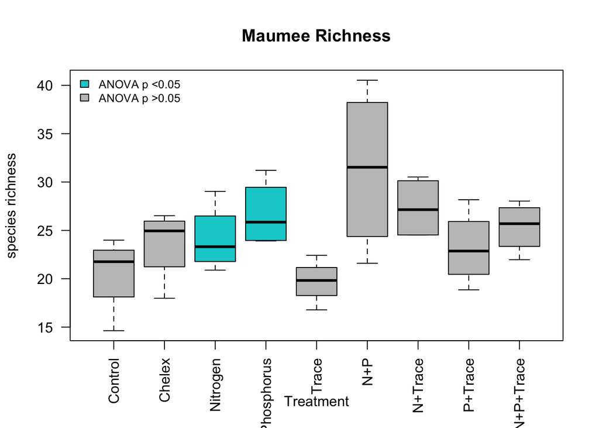

```r
par(mfrow=c(1,1))
#order treatments in a logical way
maum.hills$TREATMENT <- factor(maum.hills$TREATMENT,levels=c( "Control","Chelex","Nitrogen","Phosphorus","Trace","N+P","N+Trace","P+Trace","N+P+Trace"))

#richness
boxplot(H0~TREATMENT, data=maum.hills,
        main="Maumee Richness",
        xlab="Treatment",
        ylab="species richness",
        las=2,
        col=c("gray76","gray76","darkturquoise","darkturquoise","gray76","gray76","gray76","gray76","gray76","gray76"))
legend("topleft", bty="n", legend=c("ANOVA p <0.05","ANOVA p >0.05"),fill=c("darkturquoise","gray76"), cex=0.8)
```

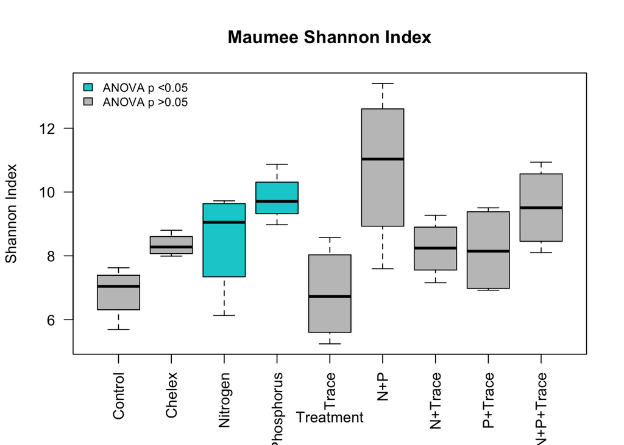

```r
#Shannon
boxplot(H1~TREATMENT, data=maum.hills,
        main="Maumee Shannon Index",
        xlab="Treatment",
        ylab="Shannon Index",
        las=2,
        col=c("gray76","gray76","darkturquoise","darkturquoise","gray76","gray76","gray76","gray76","gray76","gray76"))
legend("topleft", bty="n", legend=c("ANOVA p <0.05","ANOVA p >0.05"),fill=c("darkturquoise","gray76"), cex=0.8)
```

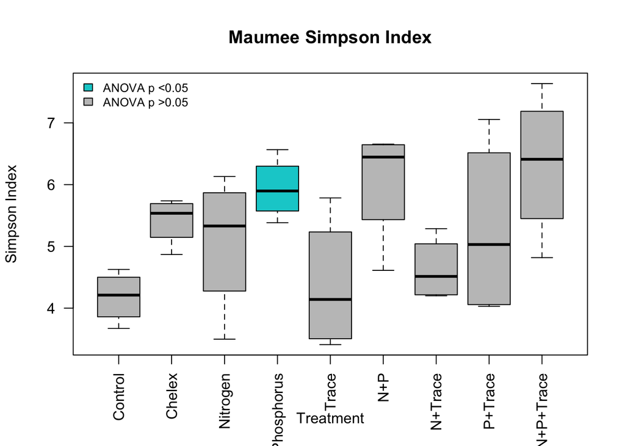

```r
#Simpson
boxplot(H2~TREATMENT, data=maum.hills,
        main="Maumee Simpson Index",
        xlab="Treatment",
        ylab="Simpson Index",
        las=2,
        col=c("gray76","gray76","gray76","darkturquoise","gray76","gray76","gray76","gray76","gray76","gray76"))
legend("topleft", bty="n", legend=c("ANOVA p <0.05","ANOVA p >0.05"),fill=c("darkturquoise","gray76"), cex=0.8)
```

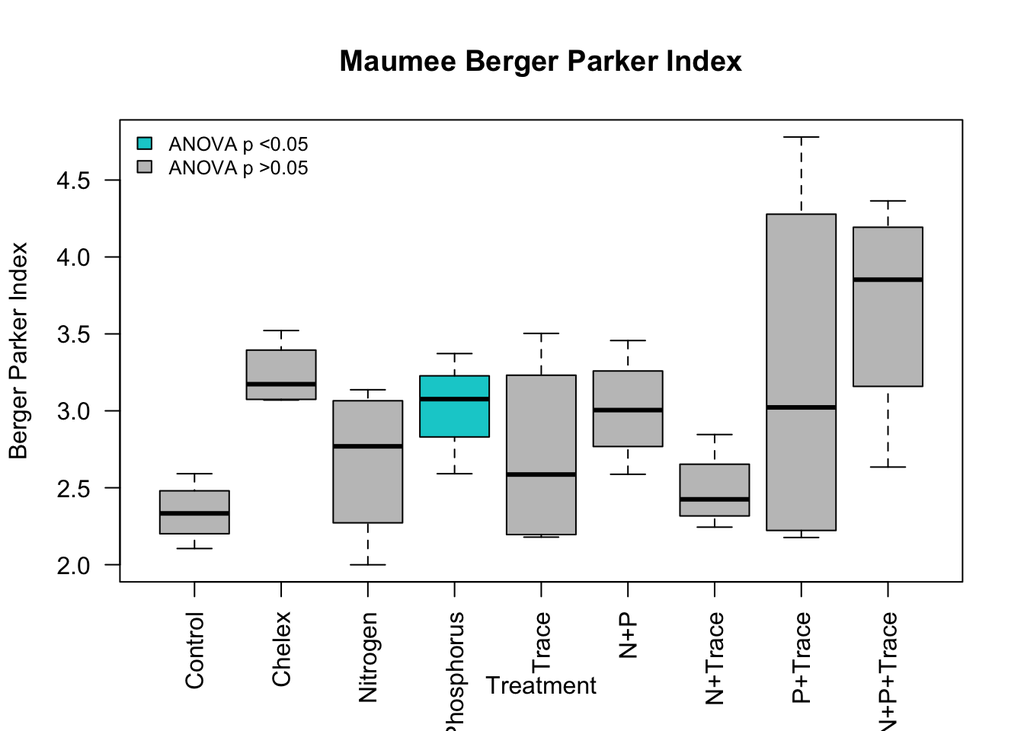

```r
#Berger Parker
boxplot(HInf~TREATMENT, data=maum.hills,
        main="Maumee Berger Parker Index",
        xlab="Treatment",
        ylab="Berger Parker Index",
        las=2,
        col=c("gray76","gray76","gray76","darkturquoise","gray76","gray76","gray76","gray76","gray76","gray76"))
legend("topleft", bty="n", legend=c("ANOVA p <0.05","ANOVA p >0.05"),fill=c("darkturquoise","gray76"), cex=0.8)
```

###Background and Interpretation

This data is from a bottle incubation experiment in which water was collected from Maumee Bay, placed into clear bottles and treated with NH4, PO4 and trace metals (Fe, Mo, Mn, Ni, Zn, Co) in replicate of 4 for each treatment. The control had no nutrients add, and the ‘chelex’ treatment removed trace metals via chelation with ‘chelex’. After a 72 hour incubation, water was sampled and analyzed for ash free dry mass, chl-a, microcystin and community composition. Community composition was comepleted by counting 400 natural units per sample and identifying down to lowest taxonomic unit, or labelled as a morphospecies.

The community composition data was rarefied to the lowest count (399) and Hill numbers were calculated. Multiway ANOVA was used to look for interactions between N, P and trace metals on all four Hill numbers. The null hypothesis was that treatment would have no effect on diversity, while the alternative was that it would. I made no specific hypotheses prior to analyses as to what specific treatments would increase or decrease diversity from the control.

The richness ANOVA indicates that N and P are significant. Using a Tukey post hoc, there is a significant relationship between N+P and trace, and N+P and control treatments. N+P increased richness (though there was great variation within the replicates) the most, and is significantly different from the control and trace treatment

The Shannon ANOVA indicates similar results, being that N+P facilitate the greatest diversity while the control and trace treatments the least.

While this diversity is interesting, I’m more interested to see if there is a community composition shift. Ordination analysis will hopefully shed light on this.

Using iNEXT

```r
library(iNEXT)
#to do it on one row (one sample)
iNEXT(as.numeric(maumee[36,4:70]), q=c(0,1,2), datatype="abundance")
```

```
## Compare 1 assemblages with Hill number order q = 0, 1, 2.
## $class: iNEXT
##
## $DataInfo: basic data information
##     site   n S.obs     SC f1 f2 f3 f4 f5 f6 f7 f8 f9 f10
## 1 site.1 415    18 0.9976  1  3  0  4  0  3  0  0  0   0
##
## $iNextEst: diversity estimates with rarefied and extrapolated samples.
##       m       method order     qD qD.LCL qD.UCL    SC SC.LCL SC.UCL
## 1     1 interpolated     0  1.000  1.000  1.000 0.175  0.148  0.201
## 10  207 interpolated     0 16.452 14.992 17.912 0.984  0.978  0.991
## 20  415     observed     0 18.000 16.227 19.773 0.998  0.992  1.003
## 30  612 extrapolated     0 18.156 15.890 20.423 1.000  0.995  1.005
## 40  830 extrapolated     0 18.166 15.283 21.049 1.000  0.997  1.003
## 41    1 interpolated     1  1.000  1.000  1.000 0.175  0.153  0.197
## 50  207 interpolated     1  7.974  7.191  8.756 0.984  0.979  0.989
## 60  415     observed     1  8.168  7.360  8.976 0.998  0.990  1.005
## 70  612 extrapolated     1  8.239  7.424  9.053 1.000  0.993  1.006
## 80  830 extrapolated     1  8.285  7.466  9.103 1.000  0.995  1.005
## 81    1 interpolated     2  1.000  1.000  1.000 0.175  0.155  0.194
## 90  207 interpolated     2  5.597  5.002  6.193 0.984  0.978  0.990
## 100 415     observed     2  5.661  5.050  6.271 0.998  0.992  1.003
## 110 612 extrapolated     2  5.681  5.066  6.296 1.000  0.995  1.005
## 120 830 extrapolated     2  5.693  5.075  6.311 1.000  0.996  1.004
##
## $AsyEst: asymptotic diversity estimates along with related statistics.
##                   Observed Estimator Est_s.e. 95% Lower 95% Upper
## Species Richness    18.000    18.166    0.535    18.008    21.527
## Shannon diversity    8.168     8.347    0.429     8.168     9.188
## Simpson diversity    5.661     5.725    0.403     5.661     6.516
##
## NOTE: Only show five estimates, call iNEXT.object$iNextEst. to show complete output.
```

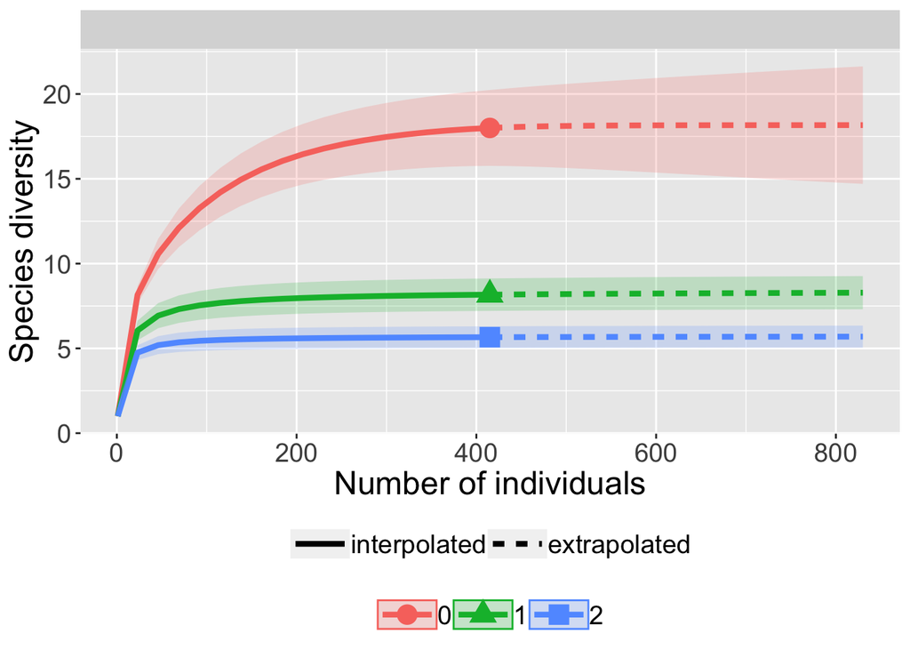

```r
some.maumee=iNEXT(as.numeric(maumee[36,4:70]), q=c(0,1,2), datatype="abundance")
ggiNEXT(some.maumee, type=1, facet.var="site")
```

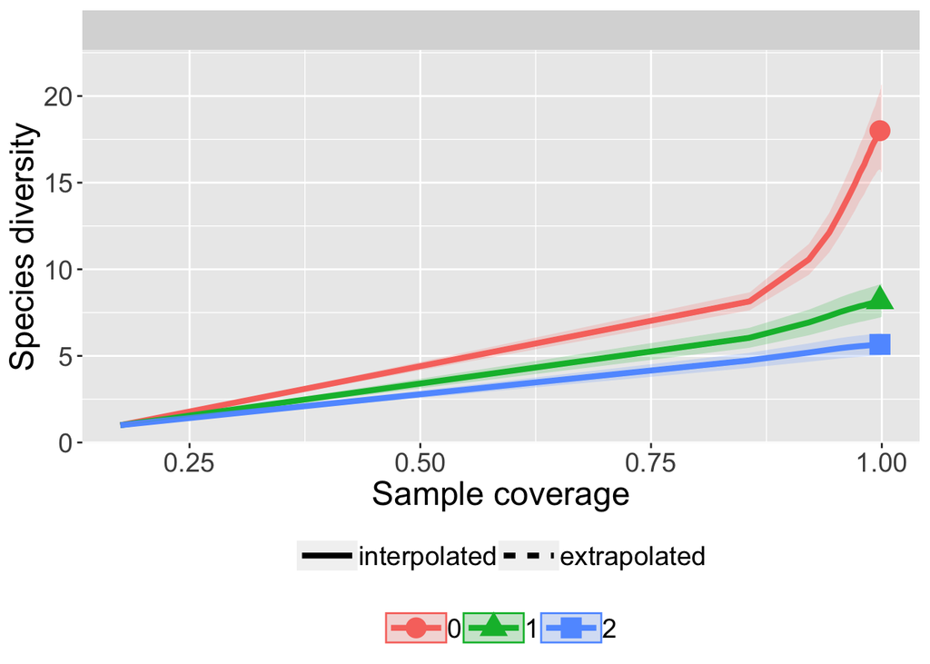

```r
ggiNEXT(some.maumee, type=3, facet.var="site")
```

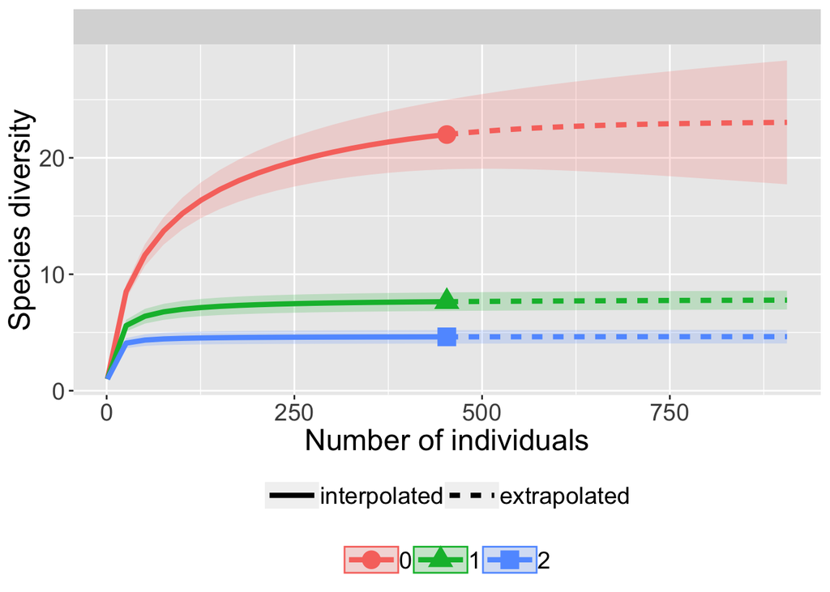

```r
some.maumee=iNEXT(as.numeric(maumee[1,4:70]), q=c(0,1,2), datatype="abundance")
ggiNEXT(some.maumee, type=1, facet.var="site")
```

```r
#since this only shows data for one sample, I'm not super interested in this. The code to run iNEXT for multiple samples was not working for me- I kept getting errors saying there are zero abundances (well obviously).. and couldn't figure out how to make it work.

#NONE OF THIS WORKS
#to run it on reformatted data for iNext- iNext takes list data
#t transposes data, switches rows and columns, apply is applying by colunm abucount function

#maumee.inext=apply(t(maumee[maum.rowsums,4:70]),2,as.abucount)
#all.maumee.data=iNEXT(maumee.inext, q=0, datatype="abundance")
#ggiNEXT(all.maumee.data, type=1, facet.var="site")
#estimateD(maumee.inext,datatype="abundance",base="coverage")
#estimateD(maumee.inext,datatype="abundance",base="coverage",level=0.9)
#estimateD(maumee.inext,datatype="abundance",base="coverage",level=0.5)

# estimateD gives an individual diversity value at a cut off of sample coverage (SC)- gives Hill numbers (as orders, 0, 1,2)

#estimateD(maumee.inext,datatype="abundance",base="size")
#estimateD(maumee.inext,datatype="abundance",base="size",level=15)
```